# Practical Machine Learning - Course Project

## Summary:

The goal of this project is to predict how well weight lifting activity is done by using data from accelerometers on the belt, forearm, arm, and dumbell of 6 participants. The data for this project is taken from the web site http://groupware.les.inf.puc-rio.br/har.

The model would be build with the training data, cross-validated against the validation data, and final outcomes will be calcualted by using the model for the test data set which contains only 20 records.

## Data loading and cleanup

. Load the training and test data . Remove unnecessary columns (timestamp, NA values etc)

## Build the predictor mode and validate

```r
#Create train (75%) and test data (25%) partitions from training pml data
library(caret)
#Just for reducing model building time during submission, reducing to 50%ge
inTrain <- createDataPartition(y=trainpml$classe, p=0.50, list=FALSE)
traindata <- trainpml[inTrain,]
testdata <- trainpml[-inTrain,]

#Build, validate and test against glm model
set.seed(54525)
#modFit <- train(classe ~ ., data=traindata, method="lm")
#modFit <- train(classe ~ ., data=traindata, medthod="glm")
#modFit <- train(classe ~ ., method="rpart", data=traindata)
#modFit <- train(classe ~ ., method="rf", data=traindata,
#                trControl=trainControl(method="cv", number=3))

modFit <- train(classe ~ total_accel_belt+total_accel_arm+total_accel_dumbbell+
                  total_accel_forearm, method="rf", data=traindata, prox=TRUE,
                trControl=trainControl(method="cv", number=3))
modFit$finalModel
```

```
##
## Call:
##  randomForest(x = x, y = y, mtry = param$mtry, proximity = TRUE)
##                Type of random forest: classification
##                      Number of trees: 500
## No. of variables tried at each split: 2
##
##         OOB estimate of  error rate: 33.13%
## Confusion matrix:
##      A    B    C   D    E class.error
## A 2133  166  229 226   36   0.2354839
## B  252 1082  247 140  178   0.4302264
## C  194  168 1097 187   65   0.3588545
## D  238  118  220 948   84   0.4104478
## E   72  209  116 106 1301   0.2788248
```

```r
#cross validate the predictor model with test data
predictions <- predict(modFit, newdata=testdata)
confusionMatrix(predictions, testdata$classe)
```

```
## Confusion Matrix and Statistics
##
##           Reference
## Prediction    A    B    C    D    E
##          A 2206  222  187  224   99
##          B  150 1091  203  109  205
##          C  215  274 1085  233  113
##          D  185  140  183  940  107
##          E   34  171   53  102 1279
##
## Overall Statistics
##
##                Accuracy : 0.6729
##                  95% CI : (0.6635, 0.6822)
##     No Information Rate : 0.2844
##     P-Value [Acc > NIR] : < 2e-16
##
##                   Kappa : 0.5856
##  Mcnemar's Test P-Value : 2.5e-16
##
## Statistics by Class:
##
##                      Class: A Class: B Class: C Class: D Class: E
## Sensitivity            0.7907   0.5748   0.6341  0.58458   0.7094
## Specificity            0.8957   0.9157   0.8969  0.92502   0.9550
## Pos Pred Value         0.7509   0.6206   0.5651  0.60450   0.7804
## Neg Pred Value         0.9150   0.8998   0.9207  0.91908   0.9359
## Prevalence             0.2844   0.1935   0.1744  0.16391   0.1838
## Detection Rate         0.2249   0.1112   0.1106  0.09582   0.1304
## Detection Prevalence   0.2995   0.1792   0.1957  0.15851   0.1671
## Balanced Accuracy      0.8432   0.7453   0.7655  0.75480   0.8322
```

```r
#library(rattle)
#fancyRpartPlot(modFit$finalModel)

#Evaluate the testpml records with new model
predict(modFit, newdata=testpml)
```

```
##  [1] A A C A C E D B A A B E B A A E A B C B
## Levels: A B C D E
```

## Out-of-Sample errors:

Out-of-sample or generalizations errors are the errors on data set that was not used to build the predictor model. Out-of-sample errors are always greater than in-sample-errors because of overfitting of in-samples in the prediction model. So out-of-sample errors can be reduced by avoiding overfitting of model with in-sample dataset.

## Plots / Graphs:

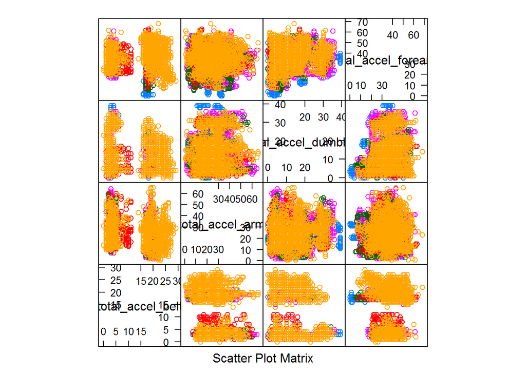